# Airlines - SDS2 Project

Giacomo Maretto

03 gennaio 2019

# Airlines Fatalities

## Introduction

In this project we are analyzing data collected from 1976 to 2001 about airline fatal accidents by the International Civil Aviation Organization in Montreal , Canada (www.icao.int).

Our goal is to get a good prediction about future fatalitis through a bayesian approach.

Our data is structured with four columns, year, fatal, miles, rate.

“Passenger miles” are in units of $10^{11}$ and the “accident rate” is the number of fatal accidents per $10^{11}$ passenger miles.

| year | fatal | miles | rate |
| --- | --- | --- | --- |
| 1976 | 24 | 3.863 | 6.213 |
| 1977 | 25 | 4.3 | 5.814 |
| 1978 | 31 | 5.027 | 6.167 |
| 1979 | 31 | 5.481 | 5.656 |
| 1980 | 22 | 5.814 | 3.784 |
| 1981 | 21 | 6.033 | 3.481 |
| 1982 | 26 | 5.877 | 4.424 |
| 1983 | 20 | 6.223 | 3.214 |
| 1984 | 16 | 7.433 | 2.152 |
| 1985 | 22 | 7.107 | 3.096 |
| 1986 | 22 | 9.1 | 2.418 |
| 1987 | 25 | 10 | 2.5 |
| 1988 | 29 | 10.6 | 2.736 |
| 1989 | 29 | 10.99 | 2.639 |
| 1990 | 27 | 10.88 | 2.482 |
| 1991 | 29 | 10.63 | 2.727 |
| 1992 | 28 | 11.96 | 2.342 |
| 1993 | 33 | 12.34 | 2.674 |
| 1994 | 27 | 13.01 | 2.075 |
| 1995 | 25 | 14.22 | 1.758 |
| 1996 | 24 | 16.37 | 1.466 |
| 1997 | 26 | 15.48 | 1.679 |
| 1998 | 20 | 18.08 | 1.106 |
| 1999 | 21 | 16.63 | 1.263 |
| 2000 | 18 | 18.88 | 0.954 |
| 2001 | 13 | 19.23 | 0.676 |

### Following three descriptive time series plot respectively about the number of fatal accidents, the miles flown and the accident rate per each year.

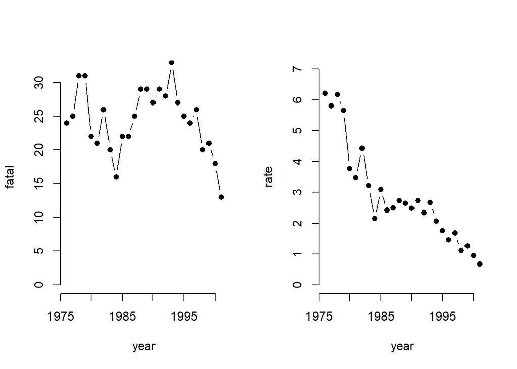

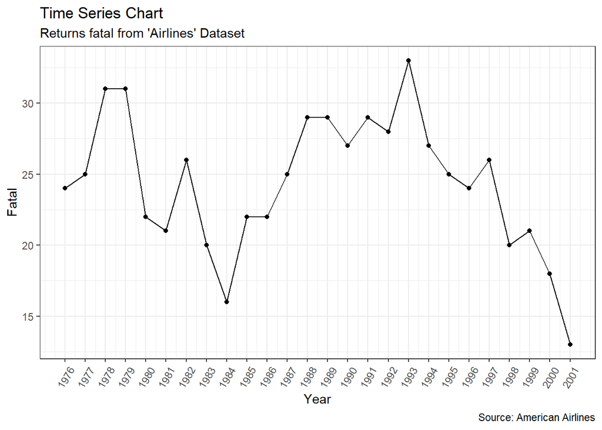

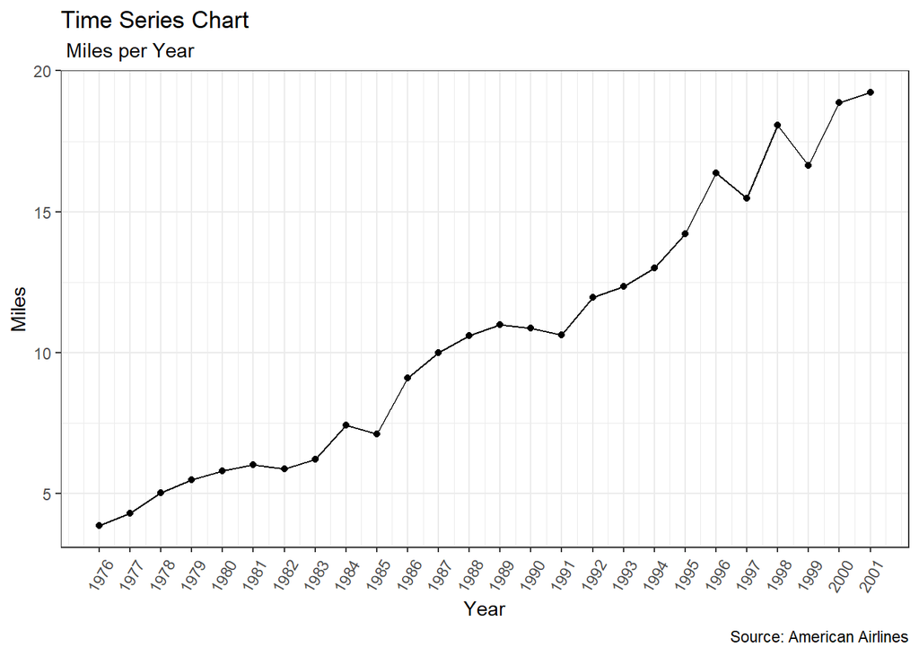

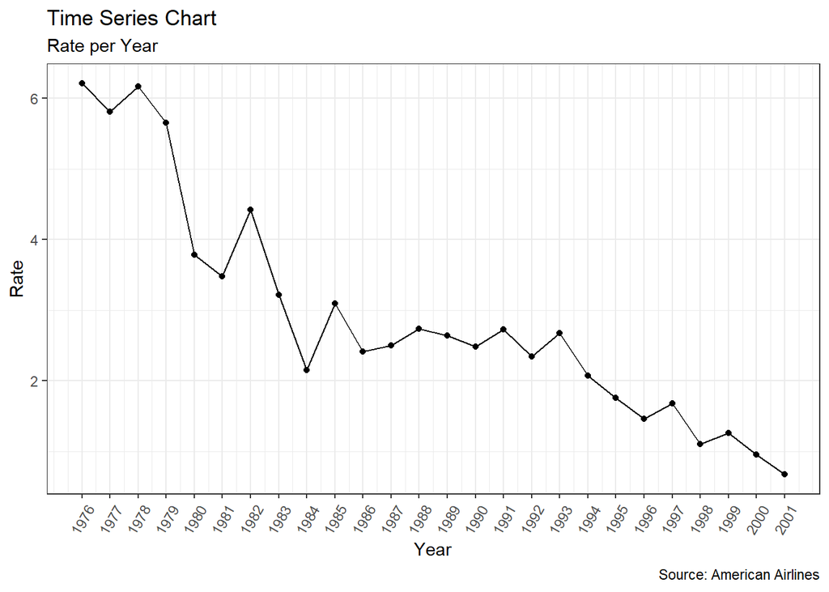

I started with the simplest model i could immagine, that simply all the years look the same. This means that the number of fatal accidents in each year are independend with a $Poisson(\theta)$ distribution. I set a non informative gamma prior distribution for $\theta$, that has $(\alpha, \beta) = (0.01,0.01)$

The model for the data is:

where /theta is the expected number of fatal accidents in an year. If the prior distribution for $\theta$ is $(\Gamma(\alpha,\beta))$ then the posterior distrubution is $\Gamma(\alpha+n\bar y,\beta+n)$, where in this case $n=26$ and $n\bar y= \sum^{26}_{i=1}y_i=634$
$$y_i|\theta \sim Poisson(\theta)$$

## Posterior distribution

The posterior distribution for $\theta$ is $\theta|y \sim \Gamma(634,26)$ and the conditional distribution of $\tilde{y}$ (the number of fatal accidents in 2002) is $Poisson(\theta)$.

So to simulate values of $\tilde{y}$ all we need to do is first generate a realized value form the posterior distribution of $\theta$ as the mean. Iterating this process will generate values of $\tilde{y}$ from the posterior predictive distribution. What we are doing here is integrating numerically, using simulation, over the posterior distrobution in $\theta$. We can simulate this easily in R.

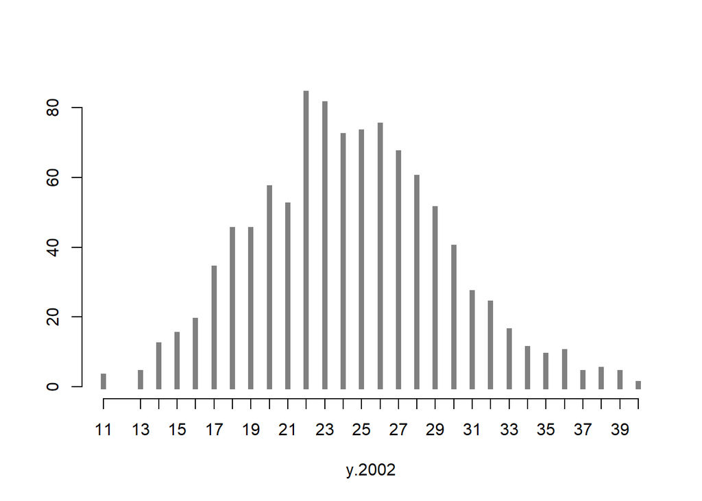

```r
theta <- rgamma(1000, 634, 26 )
y.2002 <- rpois(1000,theta)
#hist( y.2002 )
plot( table(y.2002), type="h", lwd=5, lend=2, col=gray(0.5), bty="n", ylab="" )
```

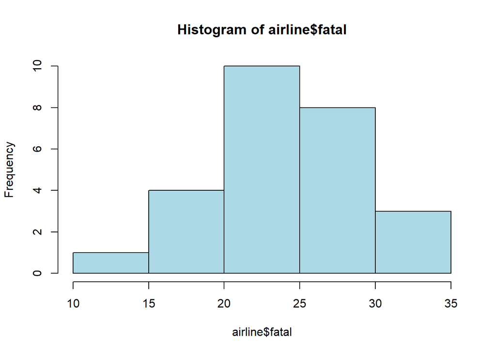

```r
hist(airline$fatal,col = "lightblue")
```

We can specify the model in R using the package rJags.

```r
a1.par <- c("mu","fatal[27]")

a1.ini <- list(list( mu=22 ),
              list( mu=23 ),
              list( mu=24 ) )

a1.dat <- list( fatal = c(airline$fatal,NA), I=27 )

# Model compilation and burn-in
a1.mod <- jags.model( file = "a1.jag",
                    data = a1.dat,
                    inits = a1.ini,
                    n.chains = 3,
                    n.adapt = 1000 )
# Sampling from the posterior
a1.res <- coda.samples( a1.mod,
                      var = a1.par,
                      n.iter = 10000,
                      thin = 10 )
summary( a1.res )
```

```
##
## Iterations = 10:10000
## Thinning interval = 10
## Number of chains = 3
## Sample size per chain = 1000
##
## 1. Empirical mean and standard deviation for each variable,
##    plus standard error of the mean:
##
##            Mean     SD Naive SE Time-series SE
## fatal[27] 24.40 4.9662  0.09067        0.08138
## mu        24.38 0.9656  0.01763        0.01763
##
## 2. Quantiles for each variable:
##
##            2.5%   25%   50%   75% 97.5%
## fatal[27] 15.00 21.00 24.00 28.00 34.00
## mu        22.54 23.72 24.35 25.02 26.34
```

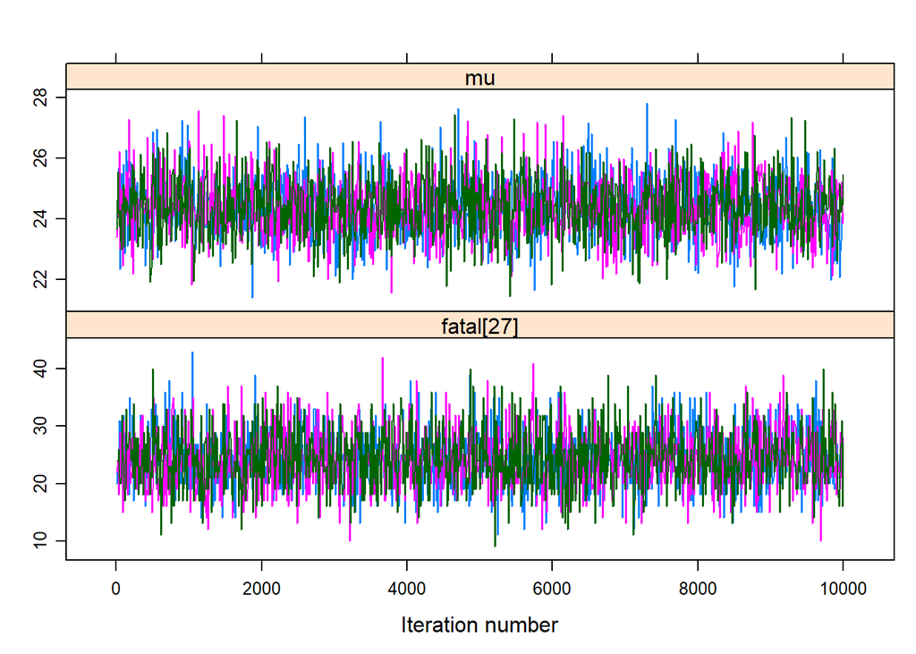

```r
print( xyplot( a1.res[,1:2] ) )
```

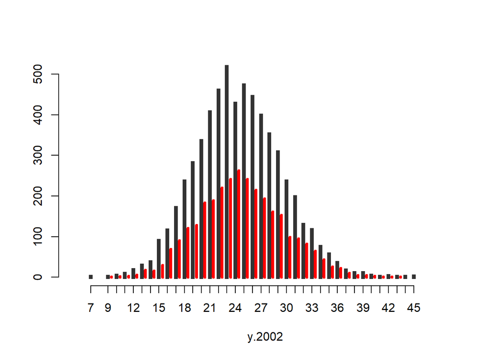

```r
theta <- rgamma(6000, 634, 26 )
y.2002 <- rpois(6000,theta)
plot( table(y.2002), type="h", lwd=5, lend=2, col=gray(0.2), bty="n", ylab="", xlim=c(5,50) )
tpr <- table( as.matrix( a1.res[,"fatal[27]"] ) )
points( as.numeric(names(tpr))+0.4, tpr, type="h", col="red", lwd=4 )
```

```r
###################
```

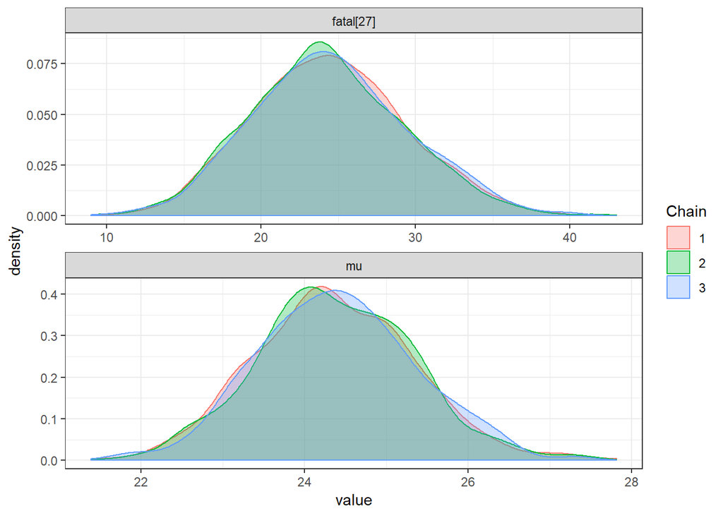

```r
result = ggs(a1.res)
ggs_density(result)
```

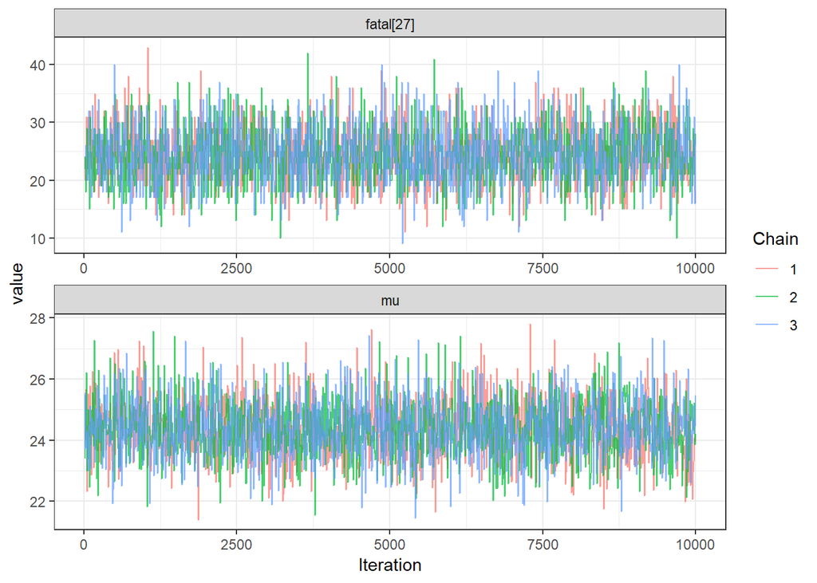

```r
ggs_traceplot(result)
```

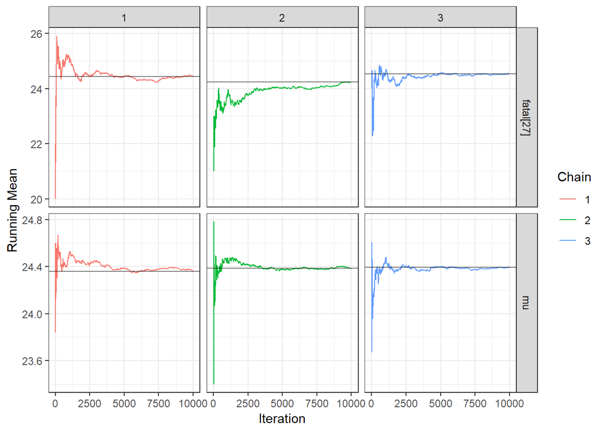

```r
ggs_running(result)
```

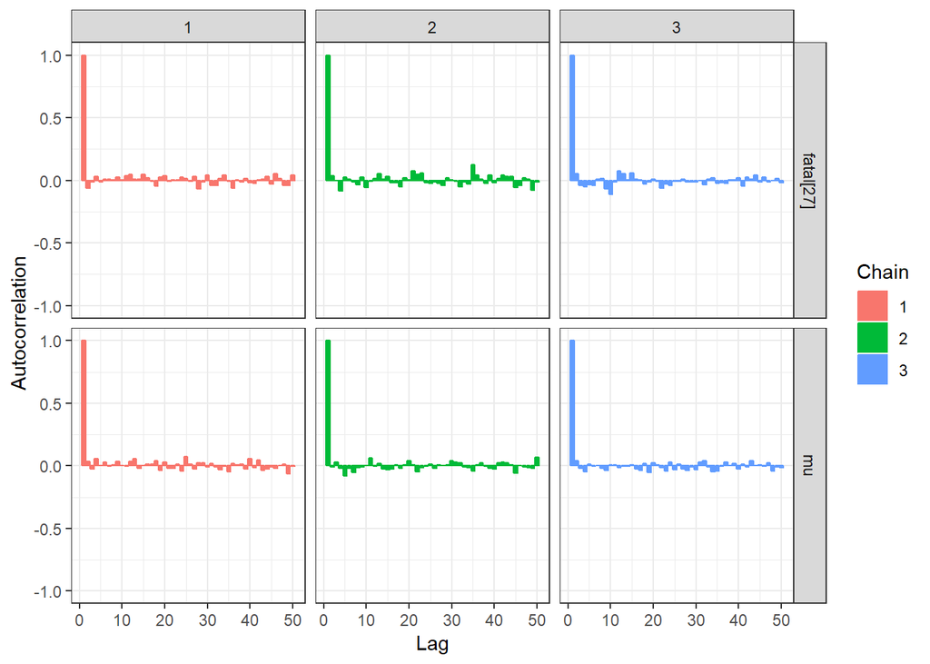

```r
ggs_autocorrelation(result)
```

```r
#ggs_pairs(result) ########mmmmmeh
```

## MODEL2

```r
a2.ini <- list( list( lambda=10 ),list( lambda=20 ),list( lambda=30 ) )
a2.dat <- list( fatal=c(airline$fatal,NA),miles=c(airline$miles,20), I=27 )
a2.par <- c("mu","fatal[27]")

# Model compilation and burn-in
a2.mod <- jags.model( file = "a2.jag",data = a2.dat,inits = a2.ini,n.chains = 3,n.adapt = 1000 )
# Sampling from the posterior
a2.res <- coda.samples( a2.mod,var = a2.par,n.iter = 10000,thin = 10 )
summary( a2.res )
```

```
##
## Iterations = 10:10000
## Thinning interval = 10
## Number of chains = 3
## Sample size per chain = 1000
##
## 1. Empirical mean and standard deviation for each variable,
##    plus standard error of the mean:
##
##             Mean     SD Naive SE Time-series SE
## fatal[27] 45.954 6.9179 0.126302       0.126339
## mu[1]      8.885 0.3606 0.006583       0.006138
## mu[2]      9.891 0.4014 0.007328       0.006833
## mu[3]     11.563 0.4692 0.008567       0.007988
## mu[4]     12.607 0.5116 0.009340       0.008709
## mu[5]     13.373 0.5427 0.009908       0.009238
## mu[6]     13.877 0.5631 0.010281       0.009586
## mu[7]     13.518 0.5486 0.010015       0.009338
## mu[8]     14.314 0.5809 0.010605       0.009888
## mu[9]     17.097 0.6938 0.012667       0.011811
## mu[10]    16.347 0.6634 0.012111       0.011293
## mu[11]    20.931 0.8494 0.015508       0.014460
## mu[12]    23.001 0.9334 0.017042       0.015890
## mu[13]    24.381 0.9894 0.018064       0.016843
## mu[14]    25.274 1.0256 0.018725       0.017460
## mu[15]    25.025 1.0155 0.018541       0.017288
## mu[16]    24.457 0.9925 0.018120       0.016896
## mu[17]    27.500 1.1160 0.020375       0.018998
## mu[18]    28.391 1.1521 0.021034       0.019613
## mu[19]    29.927 1.2145 0.022173       0.020674
## mu[20]    32.708 1.3273 0.024233       0.022595
## mu[21]    37.656 1.5281 0.027899       0.026013
## mu[22]    35.613 1.4452 0.026385       0.024602
## mu[23]    41.586 1.6876 0.030811       0.028729
## mu[24]    38.258 1.5525 0.028345       0.026429
## mu[25]    43.415 1.7618 0.032166       0.029992
## mu[26]    44.239 1.7952 0.032776       0.030561
## mu[27]    46.003 1.8668 0.034083       0.031780
##
## 2. Quantiles for each variable:
```

[output cut: 15 more lines]

```
## mu[13]    22.509 23.687 24.387 25.02 26.334
## mu[14]    23.333 24.554 25.279 25.94 27.298
## mu[15]    23.103 24.313 25.031 25.69 27.030
## mu[16]    22.579 23.761 24.463 25.10 26.416
## mu[17]    25.388 26.717 27.507 28.23 29.703
## mu[18]    26.210 27.582 28.397 29.14 30.664
## mu[19]    27.628 29.075 29.934 30.72 32.324
## mu[20]    30.196 31.777 32.715 33.57 35.327
## mu[21]    34.763 36.583 37.664 38.65 40.671
## mu[22]    32.878 34.599 35.621 36.55 38.465
## mu[23]    38.392 40.402 41.596 42.68 44.917
## mu[24]    35.320 37.169 38.267 39.27 41.322
## mu[25]    40.080 42.179 43.425 44.56 46.892
## mu[26]    40.841 42.979 44.248 45.40 47.781
## mu[27]    42.469 44.693 46.013 47.22 49.687
```

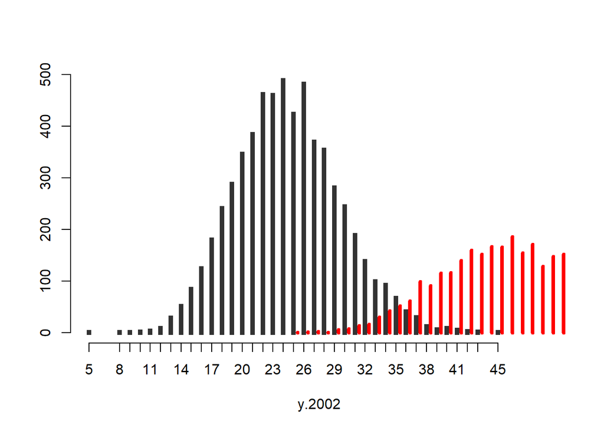

```r
#print( xyplot( a2.res[,1:2] ) )

theta <- rgamma(6000, 634, 26 )
y.2002 <- rpois(6000,theta)
plot( table(y.2002), type="h", lwd=5, lend=2, col=gray(0.2), bty="n", ylab="", xlim=c(5,50) )
tpr <- table( as.matrix( a2.res[,"fatal[27]"] ) )
points( as.numeric(names(tpr))+0.4, tpr, type="h", col="red", lwd=4 )
```

[figure not shown]

```r
result2 = ggs(a2.res)
ggs_density(result2)
```

[figure not shown]

```r
ggs_traceplot(result2)
```

[figure not shown]

```r
ggs_running(result2)
```

[figure not shown]

```r
ggs_autocorrelation(result2)
```

## MODEL 3

```r
a3.ini <- list( list( alpha=10, beta=-0.5 ),list( alpha=20, beta=-0.6 ),list( alpha=30, beta=-0.4 ) )

a3.dat <- list( fatal=c(airline$fatal,NA),miles=c(airline$miles,20), I=27 )

a3.par <- c("alpha","beta","fatal[27]")

# Model compilation and burn-in
a3.mod <- jags.model( file = "a3.jag",data = a3.dat,inits = a3.ini,n.chains = 3,n.adapt = 1000 )
# Sampling from the posterior
a3.res <- coda.samples( a3.mod,var = a3.par,n.iter = 10000,thin = 10 )
summary( a3.res )
```

```
##
## Iterations = 1010:11000
## Thinning interval = 10
## Number of chains = 3
## Sample size per chain = 1000
##
## 1. Empirical mean and standard deviation for each variable,
##    plus standard error of the mean:
##
##              Mean     SD Naive SE Time-series SE
## alpha     27.8194 2.5330  0.04625       0.067469
## beta      -0.3162 0.2136  0.00390       0.005419
## fatal[27] 21.5757 5.0703  0.09257       0.090142
##
## 2. Quantiles for each variable:
##
##              2.5%    25%     50%     75%   97.5%
## alpha     22.7906 26.159 27.8059 29.5880 32.8048
## beta      -0.7287 -0.458 -0.3205 -0.1747  0.1047
## fatal[27] 12.0000 18.000 21.0000 25.0000 32.0000
```

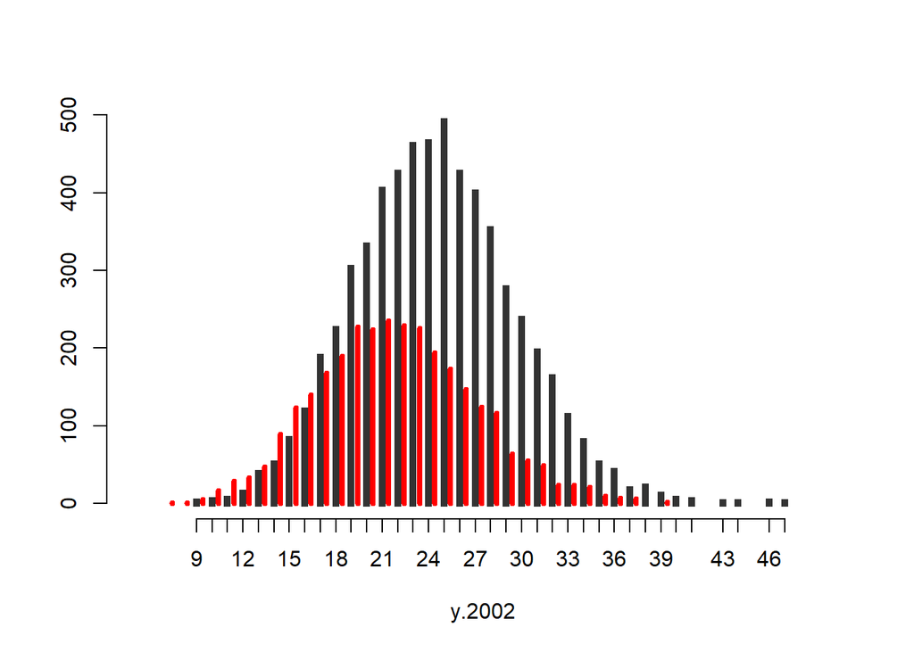

```r
#print( xyplot( a3.res[,1:2] ) )
theta <- rgamma(6000, 634, 26 )
y.2002 <- rpois(6000,theta)
plot( table(y.2002), type="h", lwd=5, lend=2, col=gray(0.2), bty="n", ylab="", xlim=c(5,50) )
tpr <- table( as.matrix( a3.res[,"fatal[27]"] ) )
points( as.numeric(names(tpr))+0.4, tpr, type="h", col="red", lwd=4 )
```

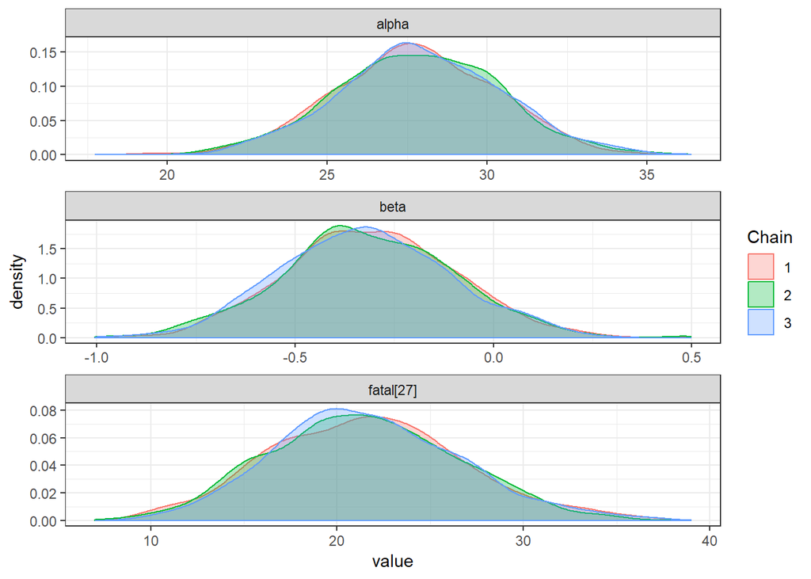

```r
result3 = ggs(a3.res)
ggs_density(result3)
```

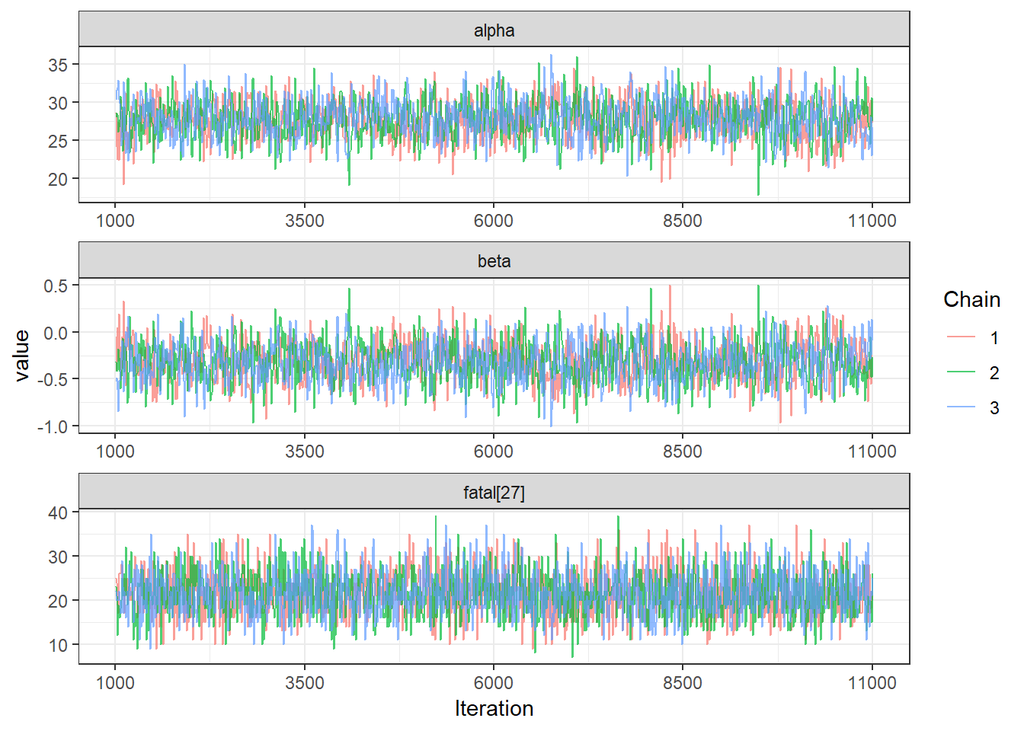

```r
ggs_traceplot(result3)
```

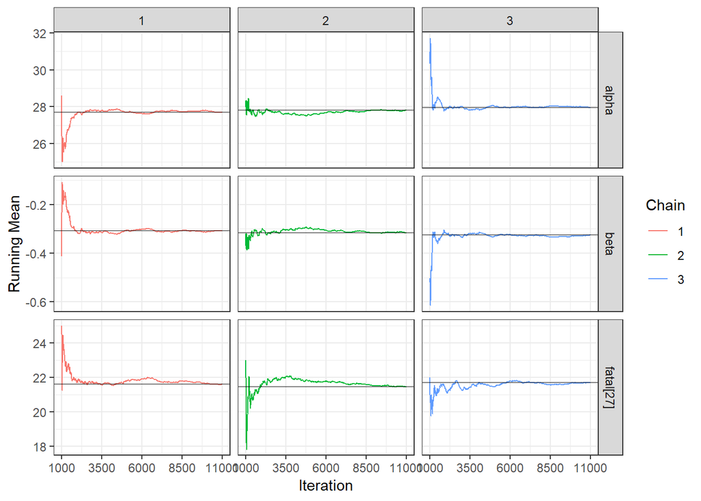

```r
ggs_running(result3)
```

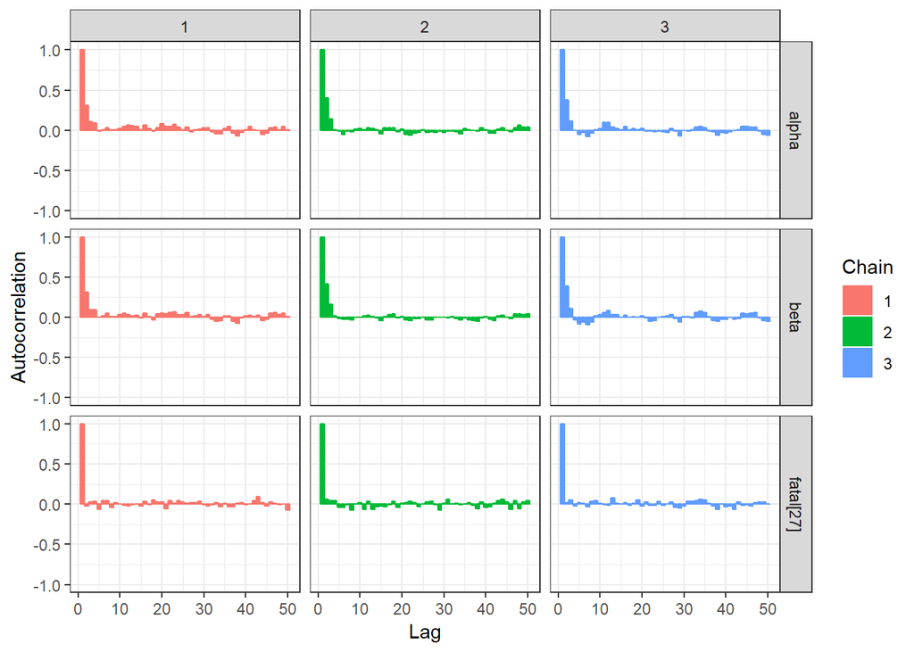

```r
ggs_autocorrelation(result3)
```